# 8 Breathing Skills

## Recap

- Green zone activities can help to keep your green zone seesaw balanced and steady. This means you are more likely to stay out of the amber and red zones, and you will experience fewer functional neurological symptoms.
- Psychological therapy teaches you green zone activities to help difficult thoughts, feelings, body sensations and behaviours.
- The skills we are offering below are an invitation only. We encourage you to try skills that are safe for you to do so, in order to find skills that suit you best.

The skills and strategies we introduce in this course are practical. Practising them will help your body learn new ways of responding to threats. Just reading about them will limit their benefits.

### Practice 1: Awareness of your breathing

Start to notice your breathing. What do you currently notice about your breathing that you weren’t aware of? For example, are you taking short and shallow breaths, or long, deep breaths. You can try this short task to explore this further:

1. Find a comfortable, quiet space and sit or lie down.
2. Become aware of your breathing.
3. Start to breathe in through your nose, and out through either your nose or mouth.
4. Place your hand on your belly and breathe normally.
5. Notice if your hand is moving in and out.

If your hand isn’t moving in and out, you’re likely to be ‘chest breathing’, which is a sign you are in the amber or red zone. If your hand is moving in and out, then you’re belly breathing. When you are in the green zone your belly naturally rises and falls with your in-breath and out-breath.

What else did you notice? For example, the speed of your breath (is it fast or slow), the depth of your breath, or the temperature of your breath going in and out of your nose.

Choose a day and time when you can try practising this skill. Write this on your calendar or put it in your phone. When you have tried this skill, make some notes about what you experienced, how you felt, and any difficulties that you had (if any).

Now that you have noticed what your normal breath is like, you can practise green zone breathing skills.

### Practice 2: Diaphragmatic Breathing

Your diaphragm is a muscle just below your ribs which helps you to breathe. Practising diaphragmatic breathing (also known as ‘belly breathing’) encourages you to take a nice, deep breath. This will help you to enter the green zone and feel more relaxed.

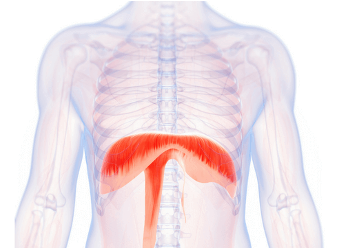

Here’s how to do it:

1. Lie on your back on a flat surface (or in bed) with your knees bent. You can use a pillow under your head and your knees if that’s more comfortable.
2. Put one hand on your chest and the other on your belly, just below your ribs.
3. Breathe in slowly through your nose, letting the air in deeply, towards your lower belly. The hand on your chest should stay still and the hand on your belly should rise.
4. As you breathe out, let your belly lower. The hand on your belly should move down.

You can also practise this sitting in a chair, with your knees bent and your shoulders, head and neck relaxed.

Choose a day and time when you can try practising this skill. Write this on your calendar or put it in your phone. When you have tried this skill, make some notes about what you experienced, how you felt, and any difficulties that you had (if any).

### Practice 3: Square Breathing

If you feel able to, you can also practise the ‘Square Breathing’ activity. This will encourage your body to be more relaxed and to do slower, more controlled breathing, which is what we do when we are in the green zone. This is a good skill to practise if you’re noticing that you’re in the amber zone and want to try to bring yourself down to the green zone. If you find 4 seconds difficult, try lowering the time, for example 3 seconds or 2 seconds.

1. Breathe in for 4 seconds
2. Hold breath for 4 seconds
3. Breathe out for 4 seconds
4. Hold for 4 seconds
5. Repeat.

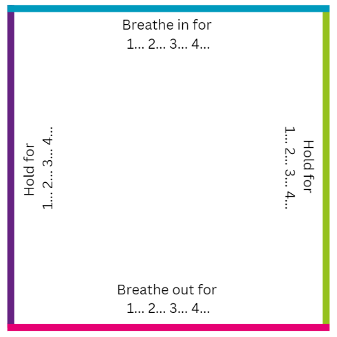

To help yourself feel even more relaxed, you could try practising making your out-breath longer. There are different variations of this skill, depending on what works best for you:

1. Breathe in for 2 seconds
2. Breathe out for 4 seconds
3. Repeat.

Or

1. Breathe in for 3 seconds
2. Breathe out for 6 seconds
3. Repeat.

Or

1. Breathe in for 4 seconds
2. Breathe out for 8 seconds
3. Repeat.

Choose a day and time when you can try practising this skill. Write this on your calendar or put it in your phone. When you have tried this skill, make some notes about what you experienced, how you felt, and any difficulties that you had (if any).

## Knowledge Check

**Questions**

1. Chest breathing is better than belly breathing. TRUE or FALSE?
2. Being aware of your breath helps you to know what zone you’re in. TRUE or FALSE?

**Answers**

1. Chest breathing is better than belly breathing. TRUE or FALSE?

   FALSE, belly breathing (or diaphragmatic breathing) encourages you to take a nice, deep breath. Shallow, faster breathing (or chest breathing) tells us we are going into the amber zone and places us at more risk of having functional neurological symptoms.
2. Being aware of your breath helps you to know what zone you’re in. TRUE or FALSE?

   TRUE, being aware of your breath is a skill in itself. This can be really helpful as shallow breathing (or chest breathing) is a sign of the amber or red zone. If you are aware of this, you are more able to do something about it.